# 加载数据集

```python
import pandas as pd
import numpy as np
df1 = pd.read_csv('/content/tmdb_5000_credits.csv')
df2 = pd.read_csv('/content/tmdb_5000_movies.csv')
```

第一份数据集包含的特征：

movie_id-每部电影的唯一标识符。

cast-主角和配角的姓名。

crew-导演，剪辑，作曲，作家等的姓名。

第二份数据集包含的特征:

budget-电影制作的预算

genre-电影的类型:动作,喜剧,惊悚片等

homepage-电影首页的链接

id-电影的id(与第一份数据集中的一样)

keywords-与电影相关的关键字或标签

original_language-电影制作语言

original_title-翻译或改编之前的电影标题

overview-电影的简要介绍

popularity-表示电影的受欢迎程度的数值

production._companies-电影的制作公司

production._countries-制作国家/地区

release_date-上映日期

revenue-电影在全球范围内的票房

runtime-影片时长

status-已上映或待上映

tagline-电影标语

title-电影名称

vote_average-平均评分

vote_count-评分次数

先将两份数据集通过id列合并。

```python
df1.columns = ['id','tittle','cast','crew']
df2 = df2.merge(df1,on='id')
```

查看前5条数据

```python
df2.head(5)
```

|  | budget | genres | homepage | id | keywords | original_language | original_title | overview | popularity | production_companies | ... | runtime | spoken_languages | status | tagline | title | vote_average | vote_count | tittle | cast | crew |
| --- | --- | --- | --- | --- | --- | --- | --- | --- | --- | --- | --- | --- | --- | --- | --- | --- | --- | --- | --- | --- | --- |
| 0 | 237000000 | [{"id": 28, "name": "Action"}, {"id": 12, "nam... | http://www.avatarmovie.com/ | 19995 | [{"id": 1463, "name": "culture clash"}, {"id":... | en | Avatar | In the 22nd century, a paraplegic Marine is di... | 150.437577 | [{"name": "Ingenious Film Partners", "id": 289... | ... | 162.0 | [{"iso_639_1": "en", "name": "English"}, {"iso... | Released | Enter the World of Pandora. | Avatar | 7.2 | 11800 | Avatar | [{"cast_id": 242, "character": "Jake Sully", "... | [{"credit_id": "52fe48009251416c750aca23", "de... |
| 1 | 300000000 | [{"id": 12, "name": "Adventure"}, {"id": 14, "... | http://disney.go.com/disneypictures/pirates/ | 285 | [{"id": 270, "name": "ocean"}, {"id": 726, "na... | en | Pirates of the Caribbean: At World's End | Captain Barbossa, long believed to be dead, ha... | 139.082615 | [{"name": "Walt Disney Pictures", "id": 2}, {"... | ... | 169.0 | [{"iso_639_1": "en", "name": "English"}] | Released | At the end of the world, the adventure begins. | Pirates of the Caribbean: At World's End | 6.9 | 4500 | Pirates of the Caribbean: At World's End | [{"cast_id": 4, "character": "Captain Jack Spa... | [{"credit_id": "52fe4232c3a36847f800b579", "de... |
| 2 | 245000000 | [{"id": 28, "name": "Action"}, {"id": 12, "nam... | http://www.sonypictures.com/movies/spectre/ | 206647 | [{"id": 470, "name": "spy"}, {"id": 818, "name... | en | Spectre | A cryptic message from Bond’s past sends him o... | 107.376788 | [{"name": "Columbia Pictures", "id": 5}, {"nam... | ... | 148.0 | [{"iso_639_1": "fr", "name": "Fran\u00e7ais"},... | Released | A Plan No One Escapes | Spectre | 6.3 | 4466 | Spectre | [{"cast_id": 1, "character": "James Bond", "cr... | [{"credit_id": "54805967c3a36829b5002c41", "de... |
| 3 | 250000000 | [{"id": 28, "name": "Action"}, {"id": 80, "nam... | http://www.thedarkknightrises.com/ | 49026 | [{"id": 849, "name": "dc comics"}, {"id": 853,... | en | The Dark Knight Rises | Following the death of District Attorney Harve... | 112.312950 | [{"name": "Legendary Pictures", "id": 923}, {"... | ... | 165.0 | [{"iso_639_1": "en", "name": "English"}] | Released | The Legend Ends | The Dark Knight Rises | 7.6 | 9106 | The Dark Knight Rises | [{"cast_id": 2, "character": "Bruce Wayne / Ba... | [{"credit_id": "52fe4781c3a36847f81398c3", "de... |
| 4 | 260000000 | [{"id": 28, "name": "Action"}, {"id": 12, "nam... | http://movies.disney.com/john-carter | 49529 | [{"id": 818, "name": "based on novel"}, {"id":... | en | John Carter | John Carter is a war-weary, former military ca... | 43.926995 | [{"name": "Walt Disney Pictures", "id": 2}] | ... | 132.0 | [{"iso_639_1": "en", "name": "English"}] | Released | Lost in our world, found in another. | John Carter | 6.1 | 2124 | John Carter | [{"cast_id": 5, "character": "John Carter", "c... | [{"credit_id": "52fe479ac3a36847f813eaa3", "de... |

5 rows × 23 columns

# 基于受众特征过滤

开始之前：

我们需要一个指标来对电影进行评分

计算每部电影的评分

对分数进行排序，并向用户推荐评分最高的电影

我们可以将电影的平均评分作为得分，但只使用评分也不够合理。因为假如一部电影的平均评分有8.9，但只有3人评分；而另一部电影的平均评分只有7.8，却有40人评分，因此不能认为8.9分的电影比7.8分的更好。因此，我将使用IMDB的加权评分(wr)，该评分为：

$$\left(\frac{v}{v+m}\right) \times \boldsymbol{R}+\left(\frac{m}{m+v} \times c\right)$$

其中，

V评分次数;

m能在排行榜中列出的最低评分次数;

R平均评分;

C整个数据的平均评分;

```python
C = df2['vote_average'].mean()
C
```

```
6.092171559442011
```

因此，所有电影在总分为10分的情况下，平均评分约为6。

下一步是确定m的适当值，即能在排行榜中列出的最低评分次数。我们将使用第90个百分位数作为我们的分界点。换句话说，要使电影在图表中出现，其评分次数必须比列表中至少90%的电影多。

```python
m= df2['vote_count'].quantile(0.9)
m
```

```
1838.4000000000015
```

现在我们可以筛选出符合排行榜的电影

```python
q_movies = df2.copy().loc[df2['vote_count'] >= m]
q_movies.shape
```

```
(481, 23)
```

我们看到有481部电影符合此排行榜的资格。现在，我们需要计算每个合格电影的指标。

为此，我们将定义一个函 数weighted_rating0，并定义一个新特征score，通过将该函数应用于合格电影的DataFrame来计算值：

```python
def weighted_rating(x, m=m, C=C):
  v = x['vote_count']
  R = x['vote_average']
  #通过IMDB公式计算
  return (v/(v+m) * R) + (m/(m+v) * C)
```

```python
q_movies['score'] = q_movies.apply(weighted_rating, axis=1)
```

最后，让我们根据‘score特征对DataFrame进行排序，并输出标题，评分次数，平均评分和score（加权评分)的前10名电影。

```python
#根据score排序
q_movies = q_movies.sort_values('score', ascending=False)

#输出top10的电影
q_movies[['title', 'vote_count', 'vote_average', 'score']].head(10)
```

|  | title | vote_count | vote_average | score |
| --- | --- | --- | --- | --- |
| 1881 | The Shawshank Redemption | 8205 | 8.5 | 8.059258 |
| 662 | Fight Club | 9413 | 8.3 | 7.939256 |
| 65 | The Dark Knight | 12002 | 8.2 | 7.920020 |
| 3232 | Pulp Fiction | 8428 | 8.3 | 7.904645 |
| 96 | Inception | 13752 | 8.1 | 7.863239 |
| 3337 | The Godfather | 5893 | 8.4 | 7.851236 |
| 95 | Interstellar | 10867 | 8.1 | 7.809479 |
| 809 | Forrest Gump | 7927 | 8.2 | 7.803188 |
| 329 | The Lord of the Rings: The Return of the King | 8064 | 8.1 | 7.727243 |
| 1990 | The Empire Strikes Back | 5879 | 8.2 | 7.697884 |

至此，我们做了第一个推荐系统（尽管很基本）。在这些系统的“现在趋势”标签下，我们可以通过按“受欢迎度”列对数据集进行排序，来找到非常受欢迎的电影。

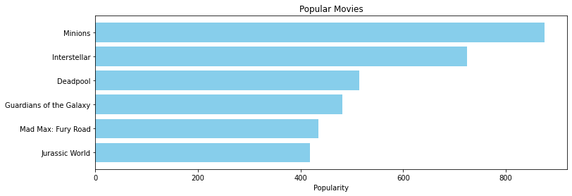

```python
pop= df2.sort_values('popularity', ascending=False)
import matplotlib.pyplot as plt
plt.figure(figsize=(12,4))

plt.barh(pop['title'].head(6),pop['popularity'].head(6), align='center', color='skyblue')
plt.gca().invert_yaxis()
plt.xlabel("Popularity")
plt.title("Popular Movies")
```

要知道的是，虽然基于受众特征的推荐系统向所有用户提供了推荐电影的榜单。但因为他们对特定用户的兴趣和 爱好不敏感，所以我们要继续使用更完善的系统一一基于内容的过滤。

# 基于内容的过滤

在此推荐器系统中，通过电影的内容（概述，演员，制作人员，关键字，标签等）查找其与其他电影的相似性。 然后，推荐最可能相似的电影。

## 3.1 基于情节描述的推荐系统

我们将根据所有电影的情节描述计算成对相似度得分，并根据相似度得分推荐电影。“情节描述”在数据集的“overview“特征列已经给出。

```python
df2['overview'].head(5)
```

```
0    In the 22nd century, a paraplegic Marine is di...
1    Captain Barbossa, long believed to be dead, ha...
2    A cryptic message from Bond’s past sends him o...
3    Following the death of District Attorney Harve...
4    John Carter is a war-weary, former military ca...
Name: overview, dtype: object
```

转换每个overview的词向量：为每个概述计算词频-逆文件逆频率（TF-1DF) 向量。

```python
# 从 scikit-learn 导入 TfIdfvectorizer
from sklearn.feature_extraction.text import TfidfVectorizer

# 定义一个TF-IDE矢量化器对象。删除所有英语停用词，例如”the”, "a"
tfidf = TfidfVectorizer(stop_words='english')

# 用空字符串替换NaN
df2['overview'] = df2['overview'].fillna('')

# 通过拟合和转换数据来构造所需的TF-IDF矩阵
tfidf_matrix = tfidf.fit_transform(df2['overview'])

# 输出tfidf_matrix的shape
tfidf_matrix.shape
```

```
(4803, 20978)
```

我们看到数据集中使用了20，000多个不同的词来描述4800部电影。

有了这个矩阵，我们现在可以计算一个相似度得分。 有几个候选方案，例如欧几里得，皮尔逊和余弦相似度得分 没有哪个分数是最好的正确答案，不同的分数在不同的情况下效果很好，尝试使用不同的指标是一个很好的分析方法。

我们将使用余弦相似度来计算表示两个电影之间相似度的数值。 选择使用余弦相似度评分，是因为它与幅度无关，并且相对容易且快速地进行计算。数学公式如下： $$\text { similarity }=\cos (\theta)=\frac{\mathbf{A} \cdot \mathbf{B}}{\|\mathbf{A}\|\|\mathbf{B}\|}=\frac{\sum_{i=1}^{n} A_{i} B_{i}}{\sqrt{\sum_{i=1}^{n} A_{i}^{2}} \sqrt{\sum_{i=1}^{n} B_{i}^{2}}}$$

由于我们使用了TF-DF矢量化器，因此计算点积将直接为我们提供余弦相似度评分。

因此，我们将使用sklearn的linear_kernel0代替cosine_similarities0，因为它速度更快。

```python
# 导入 linear_ kernel
from sklearn.metrics.pairwise import linear_kernel

# 计算余弦相似度矩阵
cosine_sim = linear_kernel(tfidf_matrix, tfidf_matrix)
```

我们将定义一个函数，该函数以电影标题作为输入并输出10个最相似电影的列表。

为此，我们需要电影标题和DataFrame索引的反向映射。

换句话说，我们需要一种机制来确定电影在我们的元数据DataFrame中的索引。

```python
# 构造索引和电影标题的反向映射
indices = pd.Series(df2.index, index=df2['title']).drop_duplicates()
```

现在，就是定义推荐系统的好时候，以下是我们将遵循的步骤：

1. 根据给定的标题获取电影的索引。
2. 获取该特定电影与所有电影的余弦相似度得分列表。将其转换为元组列表，其中第一个元素是其位置，第二个元素是相似度得分。
3. 根据相似度得分对上述元组列表进行排序；也就是第二个元素。
4. 获取此列表的前10个元素。忽略第一个涉及电影本身的元素（与特定电影最相似的电影是电影本身）。
5. 返回与顶部元素的索引相对应的标题。

```python
# 定义输入电影名称,输出与之最相似的电影的函数
def get_recommendations(title, cosine_sim=cosine_sim):
  # 获取与名称匹配的电影的索引
  idx = indices[title]
  # 获取所有电影与该电影的相似度得分
  sim_scores = list (enumerate (cosine_sim[idx]))
  # 根据相似度得分对电影进行排序
  sim_scores = sorted(sim_scores, key=lambda x: x[1], reverse=True)
  # 获取10部最相似的电影的相仪度得分
  sim_scores = sim_scores[1:11]
  # 获取电影索引
  movie_indices = [i[0] for i in sim_scores ]
  # 返回10部最相似的电影
  return df2 ['title'].iloc [movie_indices]
```

```python
get_recommendations('The Dark Knight Rises')
```

```
65                              The Dark Knight
299                              Batman Forever
428                              Batman Returns
1359                                     Batman
3854    Batman: The Dark Knight Returns, Part 2
119                               Batman Begins
2507                                  Slow Burn
9            Batman v Superman: Dawn of Justice
1181                                        JFK
210                              Batman & Robin
Name: title, dtype: object
```

```python
get_recommendations('The Avengers')
```

```
7               Avengers: Age of Ultron
3144                            Plastic
1715                            Timecop
4124                 This Thing of Ours
3311              Thank You for Smoking
3033                      The Corruptor
588     Wall Street: Money Never Sleeps
2136         Team America: World Police
1468                       The Fountain
1286                        Snowpiercer
Name: title, dtype: object
```

尽管我们做的系统在查找具有类似剧情描述的电影方面做得不错，但是推荐的质量却不是那么好。

“The Dark Knight Rises”将重现所有蝙蝠侠电影，而喜欢该电影的人们更有可能更喜欢 Christopher Nolan 的其他电影，这是本系统无法捕获的。

## 3.2基于品质、类型和关键字的推荐系统

从演员，剧组和关键字特征中，我们需要提取与该电影相关的三个最重要的演员，导演和关键字。我们现在的数据是“字符串化”列表的形式，需要将其转换为安全且可用的结构。

```python
# 将字符串化的特征解析为它们对应的python对象
from ast import literal_eval

features = ['cast', 'crew', 'keywords', 'genres']
for feature in features:
  df2[feature] = df2[feature].apply(literal_eval)
```

接下来，我们将定义从每个特征中提取所需信息的函数。

```python
# 从剧组特征中获取导演的姓名，如果没有列出director，则返回NaN
def get_director(x):
  for i in x:
    if i['job'] == 'Director':
      return i['name']
  return np.nan
```

```python
# 返回列表的前3个元素或整个列表
def get_list(x):
  if isinstance(x, list):
    names = [i['name'] for i in x]
    # 检查是否存在3个以上的元素,如果是,则仅返回前三个;如果否,则返回整个列表.
    if len(names)>3:
      names = names[:3]
    return names
    # 如果数据丢失/格式错误,则返回空列表
  return []
```

```python
# 以合适的形式定义新的导演，演员，类型和关键字特征。
df2['director'] = df2['crew'].apply(get_director)

features = ['cast', 'keywords', 'genres']
for feature in features:
  df2[feature] = df2[feature].apply(get_list)
```

```python
# 输出前三部电影的新特征
df2[['title', 'cast', 'director', 'keywords', 'genres']].head(3)
```

|  | title | cast | director | keywords | genres |
| --- | --- | --- | --- | --- | --- |
| 0 | Avatar | [Sam Worthington, Zoe Saldana, Sigourney Weaver] | James Cameron | [culture clash, future, space war] | [Action, Adventure, Fantasy] |
| 1 | Pirates of the Caribbean: At World's End | [Johnny Depp, Orlando Bloom, Keira Knightley] | Gore Verbinski | [ocean, drug abuse, exotic island] | [Adventure, Fantasy, Action] |
| 2 | Spectre | [Daniel Craig, Christoph Waltz, Léa Seydoux] | Sam Mendes | [spy, based on novel, secret agent] | [Action, Adventure, Crime] |

下一步是将电影名称和关键字实例转换为小写并去除它们之间的所有空格。

这样做是为了使我们的矢量化程序不会将“Johnny Depp”和“Johnny Galecki”的Johnny认作相同的。

```python
# 将所有字符串转换为小写并去除空格的函数
def clean_data(x):
  if isinstance(x, list):
    return [str.lower(i.replace(" ", "")) for i in x]
  else:
    #检查目录是否存在.如果不存在,则返回空字符串.
    if isinstance(x, str):
      return str.lower(x.replace(" ", ""))
    else:
      return ''
```

```python
# 对特征应用clean_data函数
features = ['cast', 'keywords', 'director', 'genres']

for feature in features:
  df2[feature] = df2[feature].apply(clean_data)
```

现在，就可以创建“metadata soup“， 它是一个字符串，包含我们要提供给矢量化器的所有元数据（即演员，导演和关键字)。

```python
def create_soup(x):
  return ' '.join(x['keywords']) + ' ' + ' '.join(x['cast']) + ' ' + x['director']

df2['soup'] = df2.apply(create_soup, axis=1)
```

后续步骤与我们对基于情节描述的推荐器所做的相同。

一个重要的区别是我们使用CountCountizer0而不是TF-IDF，这是因为我们不希望减轻演员/导演在相对较多的电影中的表演或导演的影响。

```python
# 导入Countvectorizer并创建计数矩阵
from sklearn.feature_extraction.text import CountVectorizer

count = CountVectorizer (stop_words='english')
count_matrix = count.fit_transform (df2['soup'])
```

```python
# 根据count_matrix计算余弦相似度矩阵
from sklearn.metrics.pairwise import cosine_similarity

cosine_sim2 = cosine_similarity(count_matrix, count_matrix)
```

```python
# 重置主Datarrame的索引，像前面一样构造反向映射
df2 = df2.reset_index()
indices = pd.Series(df2.index, index=df2['title'])
```

现在，我们可以通过传入新的cosine_sim2矩阵作为第二个参数来重用 get_recommendations() 函数。

```python
get_recommendations('The Dark Knight Rises', cosine_sim2)
```

```
65                         The Dark Knight
119                          Batman Begins
1196                          The Prestige
1246                     Quest for Camelot
1775                         The Statement
2460                            The Unborn
317                     The Flowers of War
2793                  The Killer Inside Me
3172                         The Contender
9       Batman v Superman: Dawn of Justice
Name: title, dtype: object
```

```python
get_recommendations('The Godfather', cosine_sim2)
```

```
867     The Godfather: Part III
1525             Apocalypse Now
4124         This Thing of Ours
2731     The Godfather: Part II
2649          The Son of No One
4147           Small Apartments
499               Jack and Jill
2333      Peggy Sue Got Married
2401             City of Ghosts
3069              Danny Collins
Name: title, dtype: object
```

可以看到，由于更多的元数据，我们的推荐系统已成功捕获了更多信息，并为我们提供了更好的推荐。

Marvels or DC comics粉丝更有可能会喜欢同一家制作公司的电影。

因此，在上述特征中，我们可以添加进production_company。通过在soup中多次添加特征，还可以增加Director的权重。

# 协同过滤

## 4.1 单值分解

```python
!pip install surprise
```

```
     |████████████████████████████████| 11.8 MB 5.3 MB/s
```

```python
from surprise import Reader, Dataset, SVD
from surprise.model_selection import cross_validate
from sklearn.model_selection import RepeatedKFold
reader = Reader()
ratings = pd.read_csv('/content/ratings_small.csv')
ratings.head()
```

|  | userId | movieId | rating | timestamp |
| --- | --- | --- | --- | --- |
| 0 | 1 | 31 | 2.5 | 1260759144 |
| 1 | 1 | 1029 | 3.0 | 1260759179 |
| 2 | 1 | 1061 | 3.0 | 1260759182 |
| 3 | 1 | 1129 | 2.0 | 1260759185 |
| 4 | 1 | 1172 | 4.0 | 1260759205 |

需要注意，在这份数据集中，电影的评分为5分制，与之前的评分制不同。

```python
from sklearn.model_selection import KFold

data = Dataset.load_from_df(ratings[['userId', 'movieId','rating' ]], reader)
```

```python
svd = SVD()

cross_validate(svd, data, measures=['RMSE', 'MAE'], cv=5, verbose=True)
```

```
Evaluating RMSE, MAE of algorithm SVD on 5 split(s).

                  Fold 1  Fold 2  Fold 3  Fold 4  Fold 5  Mean    Std
RMSE (testset)    0.8988  0.8931  0.8946  0.8949  0.8969  0.8957  0.0020
MAE (testset)     0.6916  0.6882  0.6903  0.6880  0.6904  0.6897  0.0014
Fit time          6.37    4.96    7.27    7.06    9.52    7.04    1.48
Test time         0.16    0.14    0.15    0.33    0.27    0.21    0.08
```

```
{'fit_time': (6.367324590682983,
  4.960206031799316,
  7.267613172531128,
  7.06239914894104,
  9.521495580673218),
 'test_mae': array([0.69158594, 0.68818234, 0.69031684, 0.68802753, 0.69042259]),
 'test_rmse': array([0.89883149, 0.89305139, 0.89461285, 0.89487924, 0.89692936]),
 'test_time': (0.15853095054626465,
  0.14372587203979492,
  0.14510774612426758,
  0.327669620513916,
  0.26865720748901367)}
```

我们得到的平均均方根误差约为0.89，对于我们的情况而言已经可以了。

接下来对数据集进行训练并得出预测。

```python
trainset = data.build_full_trainset()
svd.fit(trainset)
```

```
<surprise.prediction_algorithms.matrix_factorization.SVD at 0x7f2b9a687f90>
```

先选择ID为1的用户，并检查她/他给出的评分。

```python
ratings[ratings['userId'] == 1]
```

|  | userId | movieId | rating | timestamp |
| --- | --- | --- | --- | --- |
| 0 | 1 | 31 | 2.5 | 1260759144 |
| 1 | 1 | 1029 | 3.0 | 1260759179 |
| 2 | 1 | 1061 | 3.0 | 1260759182 |
| 3 | 1 | 1129 | 2.0 | 1260759185 |
| 4 | 1 | 1172 | 4.0 | 1260759205 |
| 5 | 1 | 1263 | 2.0 | 1260759151 |
| 6 | 1 | 1287 | 2.0 | 1260759187 |
| 7 | 1 | 1293 | 2.0 | 1260759148 |
| 8 | 1 | 1339 | 3.5 | 1260759125 |
| 9 | 1 | 1343 | 2.0 | 1260759131 |
| 10 | 1 | 1371 | 2.5 | 1260759135 |
| 11 | 1 | 1405 | 1.0 | 1260759203 |
| 12 | 1 | 1953 | 4.0 | 1260759191 |
| 13 | 1 | 2105 | 4.0 | 1260759139 |
| 14 | 1 | 2150 | 3.0 | 1260759194 |
| 15 | 1 | 2193 | 2.0 | 1260759198 |
| 16 | 1 | 2294 | 2.0 | 1260759108 |
| 17 | 1 | 2455 | 2.5 | 1260759113 |
| 18 | 1 | 2968 | 1.0 | 1260759200 |
| 19 | 1 | 3671 | 3.0 | 1260759117 |

```python
svd.predict(1, 302, 3)
```

```
Prediction(uid=1, iid=302, r_ui=3, est=2.535484077848456, details={'was_impossible': False})
```

对于影片1D为302的电影，我们获得的预测值为2.535。此推荐器系统的一个令人震惊的功能是它不在乎电影是什么（电影内容包含哪些）。它纯粹基于分配的影片ID进行工作，并尝试根据其他用户对该影片的预测来预测评分。

# 总结

我们使用受众特征过滤，基于内容的过滤和协同过滤来创建推荐系统。虽然受众特征过滤非常简单，但却无法实际使用。

**混合系统**可以利用基于内容的过滤和协同过滤，因为事实证明这两种方法几乎是互补的。该模型是非常基础的参照模型，仅提供了一个入门的框架。

```python
!jupyter nbconvert --to html *.ipynb
```